# Programa Futebol2

Érika S. Machado

13 de dezembro de 2018

Aqui nós faremos o estudo de análise de componentes principais para o resultados da Bundesliga de 2011 a 2017, que é o Campeonato da primeira divisão do futebol alemão.

### Bibliotecas Utilizadas

```r
library(rvest)
library(tidyverse)
library(knitr)
library(reshape2)
```

# Tabelas

### Fazendo uma tabela para cada ano

```r
baixandotabela = function(x,b){
  #Pegando a informação da internet
  if (x <14){
  a = paste0("https://pt.wikipedia.org/wiki/Bundesliga_de_20", x,"%E2%80%93",x+1)%>%  read_html() %>%
      html_nodes(".toccolours")%>% html_table(fill = T)%>%.[[b]]}
  else {
    a = paste0("https://pt.wikipedia.org/wiki/Bundesliga_de_20", x,"%E2%80%93",x+1)%>%  read_html() %>%
      html_nodes(".wikitable")%>% html_table(fill = T)%>%.[[b]]}

  ta = nrow(a)

  #Padronizando os nomes das variáveis
  colnames(a)[1:11] = c("Pos","Equipes", "Pts",  "J",  "V",  "E",  "D",  "GM", "GS", "SG", "X." )
  a = a %>%
    select("Pos","Equipes", "Pts",  "J",  "V",  "GM", "SG")

  #Adicionando o Ano
  da = data.frame(ANO = rep(x, ta), a)
  da
}
```

### Baixando as tabelas

```r
tab2011 = baixandotabela(11,1)
tab2012 = baixandotabela(12,1)
tab2013 = baixandotabela(13,1)
tab2014 = baixandotabela(14,2)
tab2015 = baixandotabela(15,4)
# Não foi possível usar o mesmo método para 2016
setwd("~/Estatística/6º Semestre/Análise Multivariada/trabalho/CP- FUtebol")
tab2016 = read.table("Alemão2016.txt", sep = ";", header = T) %>%
    select("Pos","Equipes", "Pts",  "J",  "V",  "GM", "SG")
tab2016 = data.frame(ANO = rep(16, nrow(tab2016)), tab2016)

kable(head(tab2011), caption = 'tab2011')
```

tab2011

| ANO | Pos | Equipes | Pts | J | V | GM | SG |
| --- | --- | --- | --- | --- | --- | --- | --- |
| 11 | 1 | Borussia Dortmund | 81 | 34 | 25 | 80 | 55 |
| 11 | 2 | Bayern de Munique | 73 | 34 | 23 | 77 | 55 |
| 11 | 3 | Schalke 04 | 64 | 34 | 20 | 74 | 30 |
| 11 | 4 | Borussia Mönchengladbach | 60 | 34 | 17 | 49 | 25 |
| 11 | 5 | Bayer Leverkusen | 54 | 34 | 15 | 52 | 8 |
| 11 | 6 | VfB Stuttgart | 53 | 34 | 11 | 48 | 10 |

```r
kable(head(tab2012), caption = 'tab2012')
```

tab2012

| ANO | Pos | Equipes | Pts | J | V | GM | SG |
| --- | --- | --- | --- | --- | --- | --- | --- |
| 12 | 1 | Bayern de Munique | 91 | 34 | 29 | 98 | 80 |
| 12 | 2 | Borussia Dortmund | 66 | 34 | 19 | 81 | 39 |
| 12 | 3 | Bayer Leverkusen | 65 | 34 | 19 | 65 | 26 |
| 12 | 4 | Schalke 04 | 55 | 34 | 16 | 58 | 8 |
| 12 | 5 | SC Freiburg | 51 | 34 | 14 | 45 | 5 |
| 12 | 6 | Eintracht Frankfurt | 51 | 14 | 11 | 49 | 3 |

```r
kable(head(tab2013), caption = 'tab2013')
```

tab2013

| ANO | Pos | Equipes | Pts | J | V | GM | SG |
| --- | --- | --- | --- | --- | --- | --- | --- |
| 13 | 1 | Bayern de Munique | 90 | 34 | 29 | 94 | 71 |
| 13 | 2 | Borussia Dortmund | 71 | 34 | 22 | 80 | 42 |
| 13 | 3 | Schalke 04 | 64 | 34 | 19 | 63 | 20 |
| 13 | 4 | Bayer Leverkusen | 61 | 34 | 19 | 60 | 19 |
| 13 | 5 | Wolfsburg | 60 | 34 | 18 | 63 | 13 |
| 13 | 6 | Borussia Mönchengladbach | 55 | 34 | 16 | 59 | 16 |

```r
kable(head(tab2014), caption = 'tab2014')
```

tab2014

| ANO | Pos | Equipes | Pts | J | V | GM | SG |
| --- | --- | --- | --- | --- | --- | --- | --- |
| 14 | 1 | Bayern de Munique | 79 | 34 | 25 | 80 | 62 |
| 14 | 2 | VfL Wolfsburg | 69 | 34 | 20 | 72 | 34 |
| 14 | 3 | Borussia Mönchengladbach | 66 | 34 | 19 | 53 | 27 |
| 14 | 4 | Bayer Leverkusen | 61 | 34 | 17 | 62 | 25 |
| 14 | 5 | Augsburg | 49 | 34 | 15 | 43 | 0 |
| 14 | 6 | Schalke 04 | 48 | 34 | 13 | 42 | 2 |

```r
kable(head(tab2015), caption = 'tab2015')
```

tab2015

| ANO | Pos | Equipes | Pts | J | V | GM | SG |
| --- | --- | --- | --- | --- | --- | --- | --- |
| 15 | 1 | Bayern de Munique | 85 | 33 | 27 | 77 | 61 |
| 15 | 2 | Borussia Dortmund | 77 | 33 | 24 | 80 | 48 |
| 15 | 3 | Bayer Leverkusen | 57 | 33 | 17 | 53 | 15 |
| 15 | 4 | Borussia Mönchengladbach | 52 | 33 | 16 | 65 | 15 |
| 15 | 5 | Mainz 05 | 49 | 33 | 14 | 46 | 4 |
| 15 | 6 | Hertha Berlim | 49 | 33 | 14 | 42 | 0 |

```r
kable(head(tab2016), caption = 'tab2016')
```

tab2016

| ANO | Pos | Equipes | Pts | J | V | GM | SG |
| --- | --- | --- | --- | --- | --- | --- | --- |
| 16 | 1 | Bayern de Munique | 82 | 34 | 25 | 89 | 67 |
| 16 | 2 | RB Leipzig | 67 | 34 | 20 | 66 | 27 |
| 16 | 3 | Borussia Dortmund | 64 | 34 | 18 | 72 | 32 |
| 16 | 4 | Hoffenheim | 62 | 34 | 16 | 64 | 27 |
| 16 | 5 | Köln | 49 | 34 | 12 | 51 | 9 |
| 16 | 6 | Hertha Berlim | 49 | 34 | 15 | 43 | 4 |

### Selecionando os times que participaram pelo menos de 5 campeonatos

```r
#juntando todas as tabelas
  todos = rbind(tab2011,tab2012,tab2013,tab2014,tab2015,tab2016)

#Pelo menos 5 campeonatos
tab = todos %>%
  select(Equipes) %>%
  table() %>%
  sort(decreasing = T) %>%
  as.data.frame() %>%
  filter(Freq >=5)
colnames(tab)[1] = "Equipes"
tab[,1]  = as.character(tab[,1])
tab = tab %>% arrange(Equipes)
kable(tab, caption = 'Equipes Selecionadas')
```

Equipes Selecionadas

| Equipes | Freq |
| --- | --- |
| Bayer Leverkusen | 6 |
| Bayern de Munique | 6 |
| Borussia Dortmund | 6 |
| Borussia Mönchengladbach | 6 |
| Eintracht Frankfurt | 5 |
| Hamburgo | 6 |
| Hannover 96 | 5 |
| Schalke 04 | 6 |
| VfL Wolfsburg | 5 |
| Werder Bremen | 6 |

### Pegando os dados das equipes selecionadas de cada tabela

```r
todosselecionado = lapply(tab$Equipes, function(x){ todos %>%
        arrange(Equipes, Pos) %>%
        filter(Equipes == x)})
todosselecionado
```

```
## [[1]]
##   ANO Pos          Equipes Pts  J  V GM SG
## 1  12   3 Bayer Leverkusen  65 34 19 65 26
## 2  15   3 Bayer Leverkusen  57 33 17 53 15
## 3  13   4 Bayer Leverkusen  61 34 19 60 19
## 4  14   4 Bayer Leverkusen  61 34 17 62 25
## 5  11   5 Bayer Leverkusen  54 34 15 52  8
## 6  16  12 Bayer Leverkusen  41 34 11 53 2
##
## [[2]]
##   ANO Pos           Equipes Pts  J  V GM SG
## 1  12   1 Bayern de Munique  91 34 29 98 80
## 2  13   1 Bayern de Munique  90 34 29 94 71
## 3  14   1 Bayern de Munique  79 34 25 80 62
## 4  15   1 Bayern de Munique  85 33 27 77 61
## 5  16   1 Bayern de Munique  82 34 25 89 67
## 6  11   2 Bayern de Munique  73 34 23 77 55
##
## [[3]]
##   ANO Pos           Equipes Pts  J  V GM SG
## 1  11   1 Borussia Dortmund  81 34 25 80 55
## 2  12   2 Borussia Dortmund  66 34 19 81 39
## 3  13   2 Borussia Dortmund  71 34 22 80 42
## 4  15   2 Borussia Dortmund  77 33 24 80 48
## 5  16   3 Borussia Dortmund  64 34 18 72 32
## 6  14   7 Borussia Dortmund  46 34 13 47  5
##
## [[4]]
##   ANO Pos                  Equipes Pts  J  V GM SG
## 1  14   3 Borussia Mönchengladbach  66 34 19 53 27
## 2  11   4 Borussia Mönchengladbach  60 34 17 49 25
## 3  15   4 Borussia Mönchengladbach  52 33 16 65 15
## 4  13   6 Borussia Mönchengladbach  55 34 16 59 16
## 5  12   8 Borussia Mönchengladbach  47 34 12 45 -4
## 6  16   9 Borussia Mönchengladbach  45 34 12 45 4
##
## [[5]]
##   ANO Pos             Equipes Pts  J  V GM  SG
## 1  12   6 Eintracht Frankfurt  51 14 11 49   3
## 2  14   9 Eintracht Frankfurt  43 34 11 56  -6
```

[output cut: 31 more lines]

```
##   ANO Pos       Equipes Pts  J  V GM  SG
## 1  14   2 VfL Wolfsburg  69 34 20 72  34
## 2  11   8 VfL Wolfsburg  44 34 11 41  -2
## 3  15   8 VfL Wolfsburg  42 33 11 44  -4
## 4  12  11 VfL Wolfsburg  43 34 10 47  -5
## 5  16  16 VfL Wolfsburg  37 34 10 34 18
##
## [[10]]
##   ANO Pos       Equipes Pts  J  V GM  SG
## 1  16   8 Werder Bremen  45 34 13 61  3
## 2  11   9 Werder Bremen  42 34 11 49  -9
## 3  14  10 Werder Bremen  43 34 11 50 -15
## 4  13  12 Werder Bremen  39 34 10 42 -24
## 5  12  14 Werder Bremen  34 34  8 50 -16
## 6  15  16 Werder Bremen  36 33  9 34 -17
```

```r
todosselecionado = do.call(rbind, todosselecionado) %>%
  mutate(Titulo = as.integer(Pos == 1))

#Corrigindo a variável SG pois ao importar estava com caracteres especiais
todosselecionado$SG = c(26,15,19,25,8,-2,80,71,62,61, 67,55,55,39,42,48,32,5,27,25,
15,16,-4,-4,-11,-8,-28,-22,-24,-25,
30,20,8,2,-1,5,-3,-9,-15,-24,
-16,-17,3,-6,-7,-17,-17,-4,-2,-13,
-17,-29,34,-2,-4,-5,-18)
tab2012$J[6] = 34
kable(head(todosselecionado), caption = 'Equipes Selecionadas')
```

Equipes Selecionadas

| ANO | Pos | Equipes | Pts | J | V | GM | SG | Titulo |
| --- | --- | --- | --- | --- | --- | --- | --- | --- |
| 12 | 3 | Bayer Leverkusen | 65 | 34 | 19 | 65 | 26 | 0 |
| 15 | 3 | Bayer Leverkusen | 57 | 33 | 17 | 53 | 15 | 0 |
| 13 | 4 | Bayer Leverkusen | 61 | 34 | 19 | 60 | 19 | 0 |
| 14 | 4 | Bayer Leverkusen | 61 | 34 | 17 | 62 | 25 | 0 |
| 11 | 5 | Bayer Leverkusen | 54 | 34 | 15 | 52 | 8 | 0 |
| 16 | 12 | Bayer Leverkusen | 41 | 34 | 11 | 53 | -2 | 0 |

### Montando a função TabelaFinal que nos dará as tabelas de temporadas

```r
TabelaFinal = function(ano){
  #Selecionando dados para a temporada
  ta = todosselecionado %>%
  filter(ANO <=ano) %>%
    arrange(Equipes)

  #Adicionando uma coluna com a frequência que cada grupo aparece por temporada
  Freq = ta %>%
    select(Equipes) %>%
    table()

  #Agrupando os dados por equipe
  quasefinal = aggregate(. ~ Equipes, ta, sum) %>%
    mutate(Freq)


  #Fazendo as novas variáveis
  tabela = quasefinal %>%
    mutate(AP = Pts/(3*J),
           PV = V/J ,
           PC = Freq/6,
           MS = SG/J,
           GJ= GM/J,
           PP = Titulo/max(Freq))

  #Selecionando somente as variáveis que iremos utilizar na análise
  rownames(tabela) = tabela$Equipes
  if (ano == 11){
    tabela = tabela %>%
    select(AP,PV, MS,GJ,PP,PC)
    tabela[,1:5] = tabela[,1:5]%>% scale()
    tabela = tabela %>% as.matrix()
  } else {
  tabela = tabela %>%
    select(AP,PV, MS,GJ,PP,PC) %>% scale()}

  tabela}
```

### Aplicando a função TabelaFinal para conseguir os dados de cada temporada

```r
T1 = TabelaFinal(11)
T2 = TabelaFinal(12)
T3 = TabelaFinal(13)
T4 = TabelaFinal(14)
T5 = TabelaFinal(15)
T6 = TabelaFinal(16)
```

Sendo que  
- AP = Aproveitamento (%) representa a porcentagem de pontos conquistados por cada equipe (calculado como sendo a pontuação obtida pelo time dividindo-se pelo máximos de pontos que poderia ter conseguido, no caso como a vitória vale 3 pontos a pontuação máxima que uma equipe pode obter seria de 3 vezes o número de jogos disputados);  
- PV - Proporção de Vitória - (calculada como sendo o número de vitórias que o time obteve dividido pelo número de jogos disputados);  
- PC - Proporção de Campeonatos disputados (número de campeonatos que a equipe disputou dividido pelo número máximo, que no para efeito de nosso estudo serão seis);  
- MS - Saldo de gols médio por jogo . (divide-se o saldo de gols que a equipe obteve pelo número de jogos disputados no período);  
- GJ - Número médio de gols por partida (divide-se o número de gols marcados pelo time pela quantidade de partidas realizadas);  
- PP - Proporção de títulos conquistados (número de títulos conquistados pelo clube dividido pelo máximo de títulos que ele poderia ter conquistado naquele período).

# Componentes principais

```r
# Usando outra função sem ser a prcomp
cpr = function(x){
  v = var(x)
  eigen(v)
}
```

### Primeira temporada

```r
cp1 = prcomp(T1)
cp1
```

```
## Standard deviations (1, .., p=6):
## [1] 1.9380087 0.8433775 0.6743369 0.2789085 0.0177910 0.0000000
##
## Rotation (n x k) = (6 x 6):
##          PC1        PC2         PC3         PC4           PC5 PC6
## AP 0.4995231 -0.2347178 -0.01298728  0.54884788 -0.6276794985   0
## PV 0.4971812 -0.2972906 -0.06810112  0.28754239  0.7596780817   0
## MS 0.3572940  0.6967156 -0.62056984 -0.04267304 -0.0006634423   0
## GJ 0.4778232 -0.3606366 -0.07596305 -0.78006331 -0.1653996546   0
## PP 0.3838144  0.4909730  0.77737781 -0.07593167  0.0393722408   0
## PC 0.0000000  0.0000000  0.00000000  0.00000000  0.0000000000   1
```

```r
summary(cp1)
```

```
## Importance of components:
##                           PC1    PC2     PC3     PC4     PC5 PC6
## Standard deviation     1.9380 0.8434 0.67434 0.27891 0.01779   0
## Proportion of Variance 0.7512 0.1423 0.09095 0.01556 0.00006   0
## Cumulative Proportion  0.7512 0.8934 0.98438 0.99994 1.00000   1
```

```r
cpr1 = cpr(T1)
```

A primeira componente principal responde por cerca de 75,12% da variância total dos dados padronizados. Se pegarmos as duas primeiras componentes principais, conseguimos atingir 89,34% da variância total.

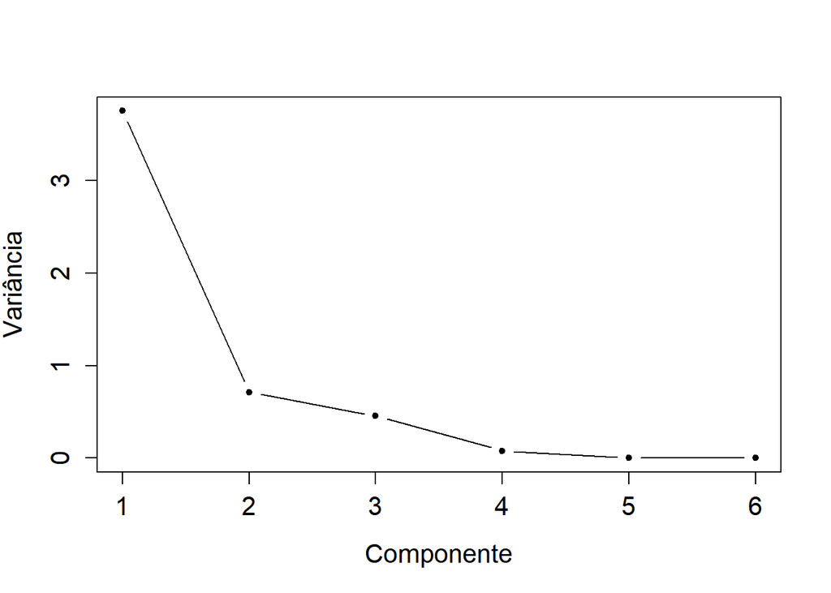

```r
plot(1:6, cp1$sdev^2, type = "b", xlab = "Componente",
 ylab = "Variância", pch = 20, cex.axis = 1.3, cex.lab = 1.3)
```

A seguir estão as correlações entre os dois primeiros componentes principais e as variáveis:

```r
cp1$sdev[1:2]*t(cp1$rotation[,1:2])
```

```
##             AP         PV        MS         GJ        PP PC
## PC1  0.9680801  0.9635414 0.6924388  0.9260256 0.7438357  0
## PC2 -0.1979557 -0.2507282 0.5875943 -0.3041528 0.4140755  0
```

O primeiro componente tem correlação forte com todas as variáveis, menos PC porque como estamos analisando somente uma temporada, essa variável ainda não se mostra significativa.

### Até Segunda temporada

```r
cp2 = prcomp(T2)
cp2
```

```
## Standard deviations (1, .., p=6):
## [1] 1.9182618 1.4578764 0.3150871 0.2654373 0.1553842 0.0314166
##
## Rotation (n x k) = (6 x 6):
##           PC1        PC2         PC3         PC4         PC5         PC6
## AP  0.5079204  0.1457647 -0.10227157  0.01084761 -0.40429618  0.73941663
## PV  0.5034788 -0.1096316 -0.59286144 -0.28005141 -0.20307158 -0.51316511
## MS  0.1129252 -0.6556828 -0.09852326  0.73675922 -0.06857161 -0.01024200
## GJ  0.5140655  0.0683681  0.01852476  0.06469734  0.84671926  0.09798008
## PP  0.2670851 -0.5674691  0.61150080 -0.47298701 -0.09017186 -0.02938429
## PC -0.3744009 -0.4583865 -0.50405616 -0.38824855  0.25600783  0.42350464
```

```r
summary(cp2)
```

```
## Importance of components:
##                           PC1    PC2     PC3     PC4     PC5     PC6
## Standard deviation     1.9183 1.4579 0.31509 0.26544 0.15538 0.03142
## Proportion of Variance 0.6133 0.3542 0.01655 0.01174 0.00402 0.00016
## Cumulative Proportion  0.6133 0.9675 0.98407 0.99581 0.99984 1.00000
```

```r
cpr2 = cpr(T2)
```

A primeira componente principal responde por 61,33% da variância total dos dados padronizados. Se pegarmos as duas primeiras componentes principais, conseguimos atingir 96,75% da variância total.

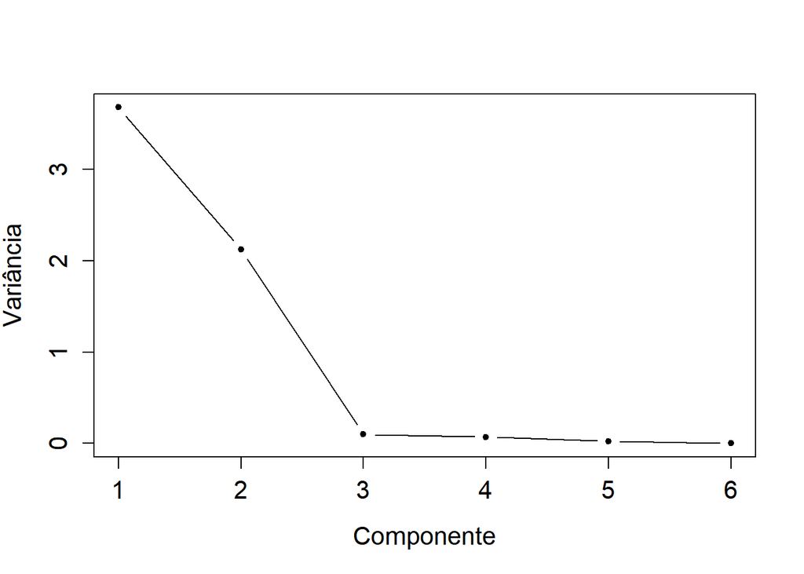

```r
plot(1:6, cp2$sdev^2, type = "b", xlab = "Componente",
 ylab = "Variância", pch = 20, cex.axis = 1.3, cex.lab = 1.3)
```

A seguir estão as correlações entre os dois primeiros componentes principais e as variáveis:

```r
cp2$sdev[1:2]*t(cp2$rotation[,1:2])
```

```
##            AP         PV         MS         GJ         PP         PC
## PC1 0.9743244  0.9658042  0.2166202 0.98611215  0.5123391 -0.7181990
## PC2 0.2125068 -0.1598293 -0.9559045 0.09967224 -0.8272998 -0.6682709
```

### Até Terceira temporada

```r
cp3 = prcomp(T3)
cp3
```

```
## Standard deviations (1, .., p=6):
## [1] 2.12572610 1.01903275 0.58896311 0.26079205 0.15170749 0.07039592
##
## Rotation (n x k) = (6 x 6):
##           PC1         PC2        PC3        PC4         PC5         PC6
## AP -0.4386757  0.27496585  0.3607290 -0.2401334 -0.09636106  0.73135657
## PV -0.4579006  0.07553735  0.3183628 -0.2260017 -0.51868277 -0.60262561
## MS -0.4202678 -0.26975387 -0.5351566 -0.6023312  0.31555045 -0.04289935
## GJ -0.4503192  0.19805517  0.2473016  0.3882191  0.69637970 -0.24732550
## PP -0.4371129  0.04009019 -0.5599219  0.5811124 -0.36907299  0.14108864
## PC -0.1655612 -0.89726677  0.3278055  0.2001265 -0.03083975  0.13799885
```

```r
summary(cp3)
```

```
## Importance of components:
##                           PC1    PC2     PC3     PC4     PC5     PC6
## Standard deviation     2.1257 1.0190 0.58896 0.26079 0.15171 0.07040
## Proportion of Variance 0.7531 0.1731 0.05781 0.01134 0.00384 0.00083
## Cumulative Proportion  0.7531 0.9262 0.98400 0.99534 0.99917 1.00000
```

```r
crp3 = cpr(T3)
```

A primeira componente principal responde por 75,31% da variância total dos dados padronizados. Se pegarmos as duas primeiras componentes principais, conseguimos atingir 92.62% da variância total.

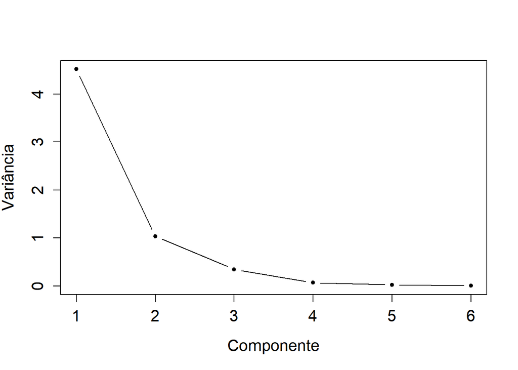

```r
plot(1:6, cp3$sdev^2, type = "b", xlab = "Componente",
 ylab = "Variância", pch = 20, cex.axis = 1.3, cex.lab = 1.3)
```

A seguir estão as correlações entre os dois primeiros componentes principais e as variáveis:

```r
cp3$sdev[1:2]*t(cp3$rotation[,1:2])
```

```
##             AP          PV         MS         GJ          PP         PC
## PC1 -0.9325045 -0.97337135 -0.8933742 -0.9572553 -0.92918224 -0.3519378
## PC2  0.2801992  0.07697503 -0.2748880  0.2018247  0.04085322 -0.9143442
```

O primeiro componente tem correlação forte com todas as variáveis, menos PC que apresenta correlação negativa fraca. Aqui já vemos a mudança no comportamento das correlações. Antes elas se apresentavam fortes e positivas, mas agora continua forte, porém com correlação negativa entre as componentes principais e as variáveis.

### Até Quarta temporada

```r
cp4 = prcomp(T4)
cp4
```

```
## Standard deviations (1, .., p=6):
## [1] 2.12785635 1.05035233 0.50065011 0.27419414 0.20177400 0.04941297
##
## Rotation (n x k) = (6 x 6):
##           PC1          PC2        PC3         PC4         PC5         PC6
## AP -0.4470037  0.209403591  0.4109044 -0.11100399 -0.24338760  0.71828685
## PV -0.4580842  0.068525167  0.3772170  0.00749425 -0.44168679 -0.66934828
## MS -0.4324545 -0.271473132 -0.3204379 -0.76910658  0.20476244 -0.05614643
## GJ -0.4449639  0.245770035  0.1292792  0.32499954  0.77946468 -0.10817230
## PP -0.4344325 -0.001043476 -0.7099023  0.45194405 -0.30409301  0.10285952
## PC -0.1288611 -0.904075648  0.2559495  0.29363056  0.06090859  0.10297153
```

```r
summary(cp4)
```

```
## Importance of components:
##                           PC1    PC2     PC3     PC4     PC5     PC6
## Standard deviation     2.1279 1.0504 0.50065 0.27419 0.20177 0.04941
## Proportion of Variance 0.7546 0.1839 0.04178 0.01253 0.00679 0.00041
## Cumulative Proportion  0.7546 0.9385 0.98028 0.99281 0.99959 1.00000
```

```r
cpr4 = cpr(T4) #usar essa medida
```

A primeira componente principal responde por cerca de 75,46% da variância total dos dados padronizados. Se pegarmos as duas primeiras componentes principais, conseguimos atingir 93,85% da variância total.

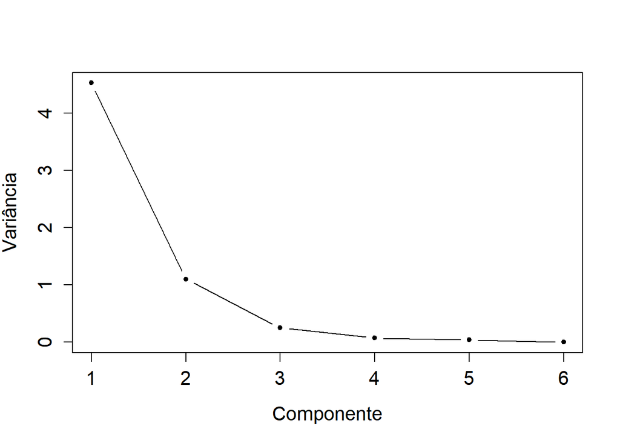

```r
plot(1:6, cp4$sdev^2, type = "b", xlab = "Componente",
 ylab = "Variância", pch = 20, cex.axis = 1.3, cex.lab = 1.3)
```

A seguir estão as correlações entre os dois primeiros componentes principais e as variáveis:

```r
cp4$sdev[1:2]*t(cp4$rotation[,1:2])
```

```
##             AP          PV         MS         GJ           PP         PC
## PC1 -0.9511597 -0.97473746 -0.9202010 -0.9468192 -0.924409935 -0.2741979
## PC2  0.2199475  0.07197557 -0.2851424  0.2581451 -0.001096017 -0.9495980
```

O primeiro componente tem correlação forte com todas as variáveis, menos PC que apresenta correlação negativa fraca.

### Até Quinta temporada

```r
cp5 = prcomp(T5)
cp5
```

```
## Standard deviations (1, .., p=6):
## [1] 2.14094057 1.01746999 0.51757072 0.28595925 0.17504407 0.02890855
##
## Rotation (n x k) = (6 x 6):
##           PC1         PC2        PC3         PC4         PC5         PC6
## AP -0.4512099  0.16635391  0.3602061 -0.02829536  0.30721308 -0.73743272
## PV -0.4578341  0.05687822  0.3196493 -0.09062270  0.49352417  0.65817819
## MS -0.4369925 -0.22316050 -0.2494444  0.82893214 -0.09670690  0.02310145
## GJ -0.4427377  0.24705565  0.2445626 -0.18946818 -0.79519439  0.12208057
## PP -0.4216755  0.05741088 -0.7874527 -0.43009766  0.10468447 -0.05356471
## PC -0.1483513 -0.92463946  0.1611235 -0.28805593 -0.09699911 -0.06846846
```

```r
summary(cp5)
```

```
## Importance of components:
##                           PC1    PC2     PC3     PC4     PC5     PC6
## Standard deviation     2.1409 1.0175 0.51757 0.28596 0.17504 0.02891
## Proportion of Variance 0.7639 0.1725 0.04465 0.01363 0.00511 0.00014
## Cumulative Proportion  0.7639 0.9365 0.98113 0.99475 0.99986 1.00000
```

```r
cpr5 = cpr(T5)
```

A primeira componente principal responde por cerca de 76,39% da variância total dos dados padronizados. Se pegarmos as duas primeiras componentes principais, conseguimos atingir 93,65% da variância total.

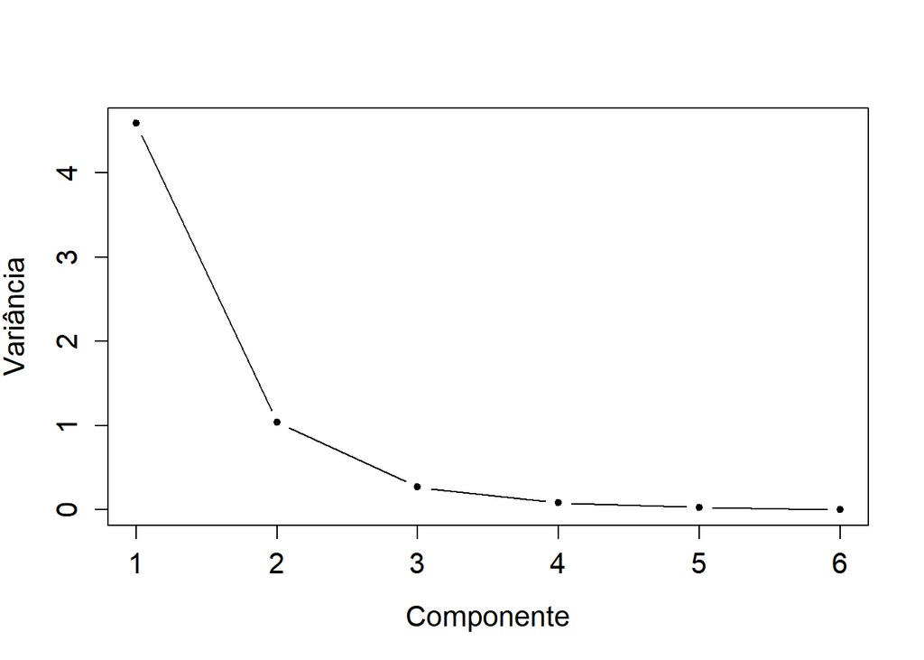

```r
plot(1:6, cp5$sdev^2, type = "b", xlab = "Componente",
 ylab = "Variância", pch = 20, cex.axis = 1.3, cex.lab = 1.3)
```

A seguir estão as correlações entre os dois primeiros componentes principais e as variáveis:

```r
cp5$sdev[1:2]*t(cp5$rotation[,1:2])
```

```
##             AP          PV         MS         GJ          PP         PC
## PC1 -0.9660136 -0.98019566 -0.9355751 -0.9478751 -0.90278228 -0.3176113
## PC2  0.1692601  0.05787189 -0.2270591  0.2513717  0.05841385 -0.9407929
```

O primeiro componente tem correlação forte com todas as variáveis, menos PC que ainda possui correlação baixa.

### Até Sexta temporada

```r
cp6 = prcomp(T6)
cp6
```

```
## Standard deviations (1, .., p=6):
## [1] 2.18709753 0.92340304 0.50160723 0.28449878 0.17026459 0.04890642
##
## Rotation (n x k) = (6 x 6):
##           PC1         PC2         PC3         PC4         PC5         PC6
## AP -0.4440797  0.13593486  0.37830264 -0.01380340  0.35589721 -0.71718110
## PV -0.4495728  0.08192966  0.27591866  0.03334411  0.49526079  0.68457697
## MS -0.4317966 -0.13976112 -0.40671952  0.78131076 -0.12484321 -0.05065038
## GJ -0.4389876  0.16972293  0.36971440 -0.13718821 -0.78099906  0.11408405
## PP -0.4091665  0.25540018 -0.69160061 -0.53471105  0.04777758 -0.02904329
## PC -0.2325983 -0.92803068  0.01830555 -0.28898898 -0.01502907 -0.02411427
```

```r
summary(cp6)
```

```
## Importance of components:
##                           PC1    PC2     PC3     PC4     PC5     PC6
## Standard deviation     2.1871 0.9234 0.50161 0.28450 0.17026 0.04891
## Proportion of Variance 0.7972 0.1421 0.04193 0.01349 0.00483 0.00040
## Cumulative Proportion  0.7972 0.9393 0.98128 0.99477 0.99960 1.00000
```

```r
cpr6 = cpr(T6)
```

A primeira componente principal responde por cerca de 79,72% da variância total dos dados padronizados. Se pegarmos as duas primeiras componentes principais, conseguimos atingir 93,93% da variância total.

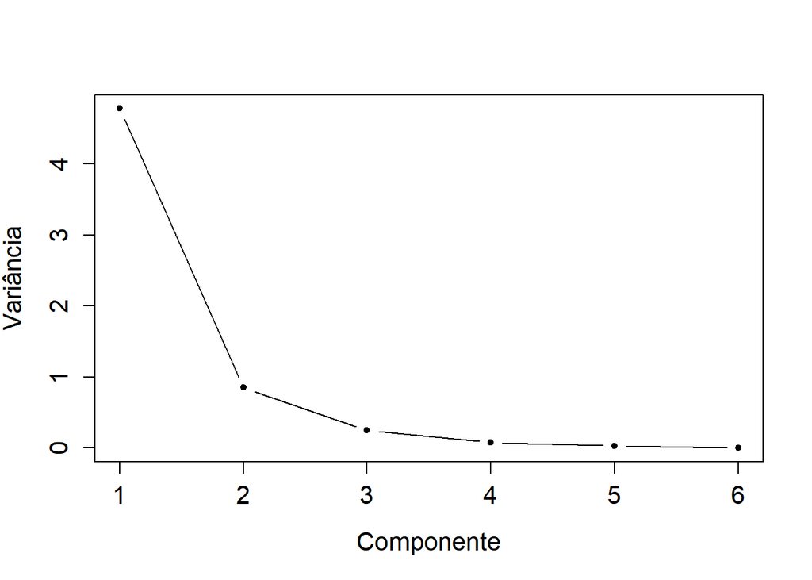

```r
plot(1:6, cp6$sdev^2, type = "b", xlab = "Componente",
 ylab = "Variância", pch = 20, cex.axis = 1.3, cex.lab = 1.3)
```

A seguir estão as correlações entre os dois primeiros componentes principais e as variáveis:

```r
cp6$sdev[1:2]*t(cp6$rotation[,1:2])
```

```
##             AP          PV         MS         GJ         PP         PC
## PC1 -0.9712455 -0.98325960 -0.9443812 -0.9601086 -0.8948870 -0.5087151
## PC2  0.1255227  0.07565409 -0.1290558  0.1567227  0.2358373 -0.8569464
```

O primeiro componente tem correlação forte com todas as variáveis, menos PC que possui correlação fraca. Notemos que da 3º temporada até a 6º, as correlações entre as componentes principais e as variáveis mantiveram-se negativas.

# Índice W

### Função para calcular os índices W:

```r
W = function(x,CP,a){
  if (a == 0 ){
    y1 = -1*x*CP$rotation[,1]
   y2 = -1*x*CP$rotation[,2]
  }else {
    y1 = x*CP$rotation[,1]
  y2 = x*CP$rotation[,2]
   }

  lambda1 = CP$sdev[1]/(CP$sdev[1]+CP$sdev[2])
  lambda2 = CP$sdev[2]/(CP$sdev[1]+CP$sdev[2])
  w1 = lambda1*y1 + lambda2*y2
  W = apply(w1,1,sum)
  cbind(x,W)
}
```

### Aplicando W em cada tabela

```r
W1 = W(T1,cp1,1)
  W2 = W(T2,cp2,1)
  W3 = W(T3,cp3,0)
  W4 = W(T4,cp4,0)
  W5 = W(T5,cp5,0)
  W6 = W(T6,cp6,0)

kable(W1, caption = 'Temporada 1')
```

Temporada 1

|  | AP | PV | MS | GJ | PP | PC | W |
| --- | --- | --- | --- | --- | --- | --- | --- |
| Bayer Leverkusen | -0.1184673 | -0.1320461 | -0.4336135 | -0.1948185 | -0.3333333 | 0.1666667 | -0.2809757 |
| Bayern de Munique | 1.1476524 | 1.2261423 | 1.4380038 | 1.2663205 | -0.3333333 | 0.1666667 | 1.6842398 |
| Borussia Dortmund | 1.6807554 | 1.5656894 | 1.4380038 | 1.4416572 | 2.6666667 | 0.1666667 | 2.6625345 |
| Borussia Mönchengladbach | 0.2813599 | 0.2075010 | 0.2433545 | -0.3701552 | -0.3333333 | 0.1666667 | 0.0439007 |
| Hamburgo | -1.3179492 | -1.3204609 | -0.4336135 | -1.1883931 | -0.3333333 | 0.1666667 | -1.4682127 |
| Hannover 96 | -0.5182946 | -0.6413667 | -0.5530784 | -0.8377197 | -0.3333333 | 0.1666667 | -0.6039941 |
| Schalke 04 | 0.5479114 | 0.7168217 | -1.3893329 | 1.0909838 | -0.3333333 | 0.1666667 | 0.1161878 |
| VfL Wolfsburg | -0.7848461 | -0.8111403 | -0.9114732 | -0.8377197 | -0.3333333 | 0.1666667 | -1.1372069 |
| Werder Bremen | -0.9181219 | -0.8111403 | 0.6017493 | -0.3701552 | -0.3333333 | 0.1666667 | -0.2990038 |

```r
kable(W2, caption = 'Até Temporada 2')
```

Até Temporada 2

|  | AP | PV | MS | GJ | PP | PC | W |
| --- | --- | --- | --- | --- | --- | --- | --- |
| Bayer Leverkusen | -0.1040046 | 0.0360481 | 0.2228904 | -0.2241914 | -0.4743416 | 0.3162278 | -0.1925364 |
| Bayern de Munique | 0.7673106 | 1.4554407 | 2.0176910 | 0.9367997 | 1.8973666 | 0.3162278 | -0.2194708 |
| Borussia Dortmund | 0.4381471 | 0.8245995 | 1.2891086 | 0.6565605 | 1.8973666 | 0.3162278 | 0.5673928 |
| Borussia Mönchengladbach | -0.3363553 | -0.3582277 | -0.0081236 | -0.6845844 | -0.4743416 | 0.3162278 | -0.6536248 |
| Eintracht Frankfurt | 2.3882334 | 1.5680909 | -1.3307419 | 2.1978763 | -0.4743416 | -2.8460499 | -2.1356303 |
| Hamburgo | -0.7816942 | -0.9102137 | -0.6833951 | -1.0248749 | -0.4743416 | 0.3162278 | 0.2089658 |
| Hannover 96 | -0.6074311 | -0.6736482 | -0.3457593 | -0.5444648 | -0.4743416 | 0.3162278 | -0.2913690 |
| Schalke 04 | -0.1040046 | 0.1937584 | -0.6123139 | 0.0760649 | -0.4743416 | 0.3162278 | 0.0133336 |
| VfL Wolfsburg | -0.7236065 | -0.9890688 | -0.6833951 | -0.8046870 | -0.4743416 | 0.3162278 | -0.1455315 |
| Werder Bremen | -0.9365946 | -1.1467791 | 0.1340389 | -0.5844990 | -0.4743416 | 0.3162278 | -1.0611069 |

```r
kable(W3, caption = 'Até Temporada 3')
```

Até Temporada 3

|  | AP | PV | MS | GJ | PP | PC | W |
| --- | --- | --- | --- | --- | --- | --- | --- |
| Bayer Leverkusen | 0.2746191 | 0.3568805 | 0.2638954 | -0.0044823 | -0.4444783 | 0.4743416 | 0.3055402 |
| Bayern de Munique | 1.8795006 | 1.9950202 | 2.0939685 | 1.9360754 | 2.5187105 | 0.4743416 | 3.5220839 |
| Borussia Dortmund | 1.0987474 | 1.1174454 | 1.2566802 | 1.3454709 | 1.0371161 | 0.4743416 | 1.8439050 |
| Borussia Mönchengladbach | -0.1157575 | -0.1111595 | 0.0725152 | -0.5107147 | -0.4444783 | 0.4743416 | -0.0886723 |
| Eintracht Frankfurt | 0.3803461 | -0.2574220 | -1.2088351 | 0.2512706 | -0.4444783 | -1.8973666 | -0.7266414 |
| Hamburgo | -1.2218245 | -1.0472394 | -0.5494705 | -1.0380402 | -0.4444783 | 0.4743416 | -1.2897206 |
| Hannover 96 | -0.7013224 | -0.5791994 | -0.4537804 | -0.6372728 | -0.4444783 | 0.4743416 | -0.5591890 |
| Schalke 04 | 0.3396819 | 0.4738904 | -0.7288894 | 0.3751921 | -0.4444783 | 0.4743416 | 0.1544669 |
| VfL Wolfsburg | -0.7989165 | -0.9009769 | -0.6750638 | -0.9536681 | -0.4444783 | -1.8973666 | -1.6568172 |
| Werder Bremen | -1.1350741 | -1.0472394 | -0.0710200 | -0.7638309 | -0.4444783 | 0.4743416 | -0.7189557 |

```r
kable(W4, caption = 'Até Temporada 4')
```

Até Temporada 4

|  | AP | PV | MS | GJ | PP | PC | W |
| --- | --- | --- | --- | --- | --- | --- | --- |
| Bayer Leverkusen | 0.3887532 | 0.4030070 | 0.3804908 | 0.1562869 | -0.4140393 | 0.4743416 | 0.4463823 |
| Bayern de Munique | 2.0648043 | 2.1527032 | 2.2184547 | 2.1282741 | 2.6912557 | 0.4743416 | 3.6397318 |
| Borussia Dortmund | 0.8077660 | 0.8404311 | 0.9899209 | 1.0347176 | 0.6210590 | 0.4743416 | 1.4614108 |
| Borussia Mönchengladbach | 0.1519199 | 0.1113910 | 0.2450619 | -0.4353093 | -0.4140393 | 0.4743416 | 0.1296393 |
| Eintracht Frankfurt | -0.0738049 | -0.5002914 | -1.0318394 | 0.1829590 | -0.4140393 | -1.8973666 | -0.9889001 |
| Hamburgo | -1.3419517 | -1.1522785 | -0.5288177 | -1.3854485 | -0.4140393 | 0.4743416 | -1.4050816 |
| Hannover 96 | -0.8682851 | -0.7634571 | -0.5868587 | -0.7938524 | -0.4140393 | 0.4743416 | -0.7679725 |
| Schalke 04 | 0.2065737 | 0.3058017 | -0.7222876 | 0.1204326 | -0.4140393 | 0.4743416 | -0.0025190 |
| VfL Wolfsburg | -0.2124390 | -0.3422339 | -0.8125735 | -0.3038434 | -0.4140393 | -1.8973666 | -1.1589420 |
| Werder Bremen | -1.1233364 | -1.0550731 | -0.1515514 | -0.7042166 | -0.4140393 | 0.4743416 | -0.6890101 |

```r
kable(W5, caption = 'Até Temporada 5')
```

Até Temporada 5

|  | AP | PV | MS | GJ | PP | PC | W |
| --- | --- | --- | --- | --- | --- | --- | --- |
| Bayer Leverkusen | 0.4073873 | 0.4100871 | 0.3476252 | 0.1518318 | -0.3939193 | 0.4743416 | 0.4479652 |
| Bayern de Munique | 2.0579232 | 2.1076949 | 2.1683453 | 2.0439650 | 2.7574351 | 0.4743416 | 3.7190256 |
| Borussia Dortmund | 0.9988293 | 1.0005594 | 1.0882571 | 1.2249820 | 0.3939193 | 0.4743416 | 1.5881228 |
| Borussia Mönchengladbach | 0.1598070 | 0.1517554 | 0.2396163 | -0.1446966 | -0.3939193 | 0.4743416 | 0.2170771 |
| Eintracht Frankfurt | -0.3360714 | -0.6312622 | -1.1068042 | 0.0543397 | -0.3939193 | -1.8973666 | -1.2105393 |
| Hamburgo | -1.1606217 | -1.0291892 | -0.2618532 | -1.2884487 | -0.3939193 | 0.4743416 | -1.2275596 |
| Hannover 96 | -0.9818137 | -0.8446666 | -0.7247482 | -0.9213184 | -0.3939193 | 0.4743416 | -0.9033915 |
| Schalke 04 | 0.1598070 | 0.2255645 | -0.7016034 | 0.0388686 | -0.3939193 | 0.4743416 | -0.0591765 |
| VfL Wolfsburg | -0.2821699 | -0.3982586 | -0.7175476 | -0.3652885 | -0.3939193 | -1.8973666 | -1.1372425 |
| Werder Bremen | -1.0230771 | -0.9922847 | -0.3312874 | -0.7942348 | -0.3939193 | 0.4743416 | -0.7485641 |

```r
kable(W6, caption = 'Até Temporada 6')
```

Até Temporada 6

|  | AP | PV | MS | GJ | PP | PC | W |
| --- | --- | --- | --- | --- | --- | --- | --- |
| Bayer Leverkusen | 0.2747050 | 0.2887942 | 0.2677055 | 0.1587652 | -0.3803194 | 0.621059 | 0.4051787 |
| Bayern de Munique | 2.1590826 | 2.2059792 | 2.1996968 | 2.1244391 | 2.7890090 | 0.621059 | 4.1714721 |
| Borussia Dortmund | 1.0471828 | 1.0237151 | 1.0911772 | 1.2572300 | 0.2535463 | 0.621059 | 1.5053204 |
| Borussia Mönchengladbach | 0.1108461 | 0.0970757 | 0.1663551 | -0.1765557 | -0.3803194 | 0.621059 | 0.2460946 |
| Eintracht Frankfurt | -0.3762532 | -0.6224049 | -1.1113227 | -0.2071311 | -0.3803194 | -1.449138 | -1.1658189 |
| Hamburgo | -1.0946873 | -0.9893292 | -0.0933552 | -1.2518949 | -0.3803194 | 0.621059 | -1.2300421 |
| Hannover 96 | -0.9234181 | -0.8083878 | -0.6587283 | -0.8303663 | -0.3803194 | -1.449138 | -1.4561303 |
| Schalke 04 | 0.0874377 | 0.1290287 | -0.6887886 | -0.0262394 | -0.3803194 | 0.621059 | -0.1099653 |
| VfL Wolfsburg | -0.3891798 | -0.4629541 | -0.7119897 | -0.5248077 | -0.3803194 | -1.449138 | -1.0025956 |
| Werder Bremen | -0.8957158 | -0.8615169 | -0.4607502 | -0.5234393 | -0.3803194 | 0.621059 | -0.6585111 |

# Gráfico de evolução

### Salvando as tabelas obtidas

```r
write.table(W1, "T1.txt")
write.table(W2, "T2.txt")
write.table(W3, "T3.txt")
write.table(W4, "T4.txt")
write.table(W5, "T5.txt")
write.table(W6, "T6.txt")

#T1 = read.table("T1", header = T)
#T2 = read.table("T2", header = T)
#T3 = read.table("T3", header = T)
#T4 = read.table("T4", header = T)
#T5 = read.table("T5.txt", header = T)
#T6 = read.table("T6.txt", header = T)
```

### Montando o gráfico

```r
#Arrumando os dados para o plot
wtodos = rbind(W1[,7], W2[,7], W3[,7], W4[,7], W5[,7], W6[,7])
Dados = melt(wtodos)
colnames(Dados) = c("Temporada", "Equipes", "W")
Dados$Temporada = factor(Dados$Temporada)
```

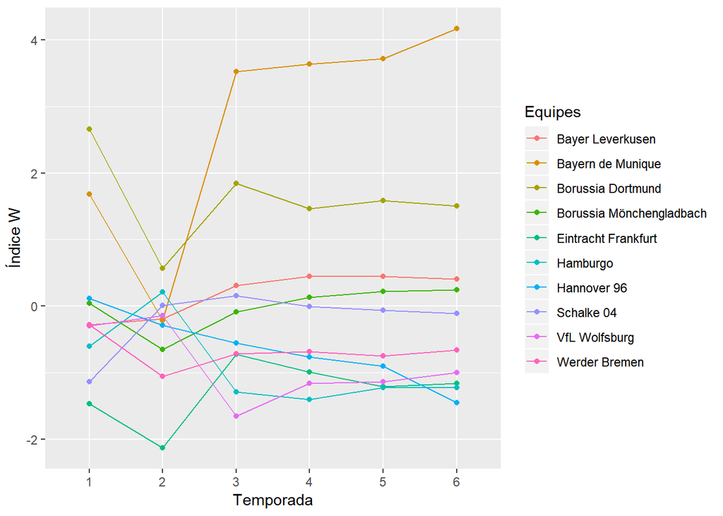

```r
#Plotando
ggplot(Dados, aes(x = Temporada, y = W, fill = Equipes,  colour=Equipes))  +
  geom_line(aes(group=Equipes))+
  geom_point(aes(group=Equipes)) +
  xlab("Temporada") +
  ylab("Índice W") +
  scale_colour_discrete()
```